# *Analisis de avistamientos de UFOs* *en USA y eventos sociopoliticos* *mundiales usando Postgres*

## Proyecto 2 - Metodos de Gran Escala

### 5/junio/2015

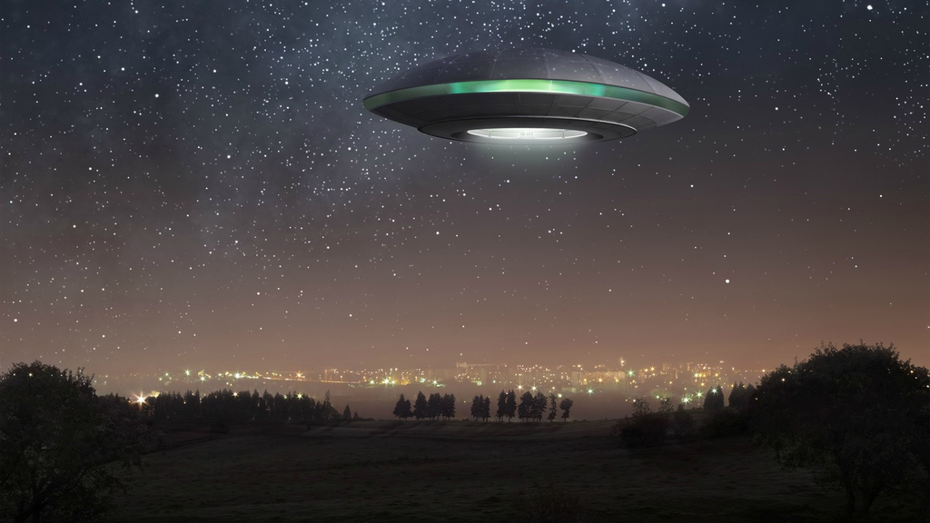

#### Fernanda Mora – Luis Roman

> *“Errors using inadequate data are much less than those using no data at all”*

## Contenido

[figure not shown]

1. Datos a analizar y configuracion de PostgreSQL  
2. Analisis de datos: UFO  
3. Analisis de datos: GDELT  
4. Conclusiones

## 1. Datos a analizar y configuracion de PostgreSQL

El objetivo de este proyecto fue analizar dos bases de datos usando PostgreSQL:

**1. Avistamientos de OVNIS en los Estados Unidos desde 1900 hasta la fecha**. Registro de variables como fecha, estado, forma, etc. Provista por el *National UFO Reporting Center.*

**2. Eventos sociopolíticos a nivel mundial**. Con variables como actores involucrados, geolocalización, importancia del evento, etc. Provista por el proyecto *Global Data on Events, Location and Tone (GDELT).*

Para llevar a cabo lo anterior primero se configuro una maquina en AWS para poder bajar los datos. Esta maquina tiene 4 GB de memoria RAM y ademas se le añadio un SSD de 100 GB para procesar la base de datos.

A dicha maquina se le instalo postgres como lo hicimos en los contenedores de clase. Adicionalmente se le instalo R para la parte del modelo predictivo. Todo se trabajo en esta maquina a excepcion de las ultimas consultas para GDELT debido a que las queries se tardaban mucho tiempo en correr (+1 hr), por lo que se uso la herramienta de Google *Big Query* que permitio correr las consultas en pocos segundos.

En este documento no se incluyen todos los comandos ejecutados para la configuracion de PostgreSQL y la carga de las bases (no fueron requeridos en el entregable), sin embargo se pueden proporcionar si son necesarios.

## 2. Analisis de datos: UFO

Primero abrimos PostgreSQL en la maquina virtual y echamos un vistazo a las variables existentes::

```r
psql -d bigdata
\d+ sightings
```

Ahora procedemos a responder las preguntas planteadas para este proyecto.

### *¿Cual fue el primer avistamiento en cada estado?*

Vemos que casi todos los estados reportan haber tenido su primer avistamiento en 1900, a excepcion de Florida, Nebraska, Kansas y California.

```r
    select MIN(date_time), state_str  from sightings group by state_str;
```

### *¿Cual fue el primer avistamiento de cada forma?*

```r
select MIN(date_time), shape from sightings group by shape;
```

```r
anio<-c(1900,1900,1974,1900,1979,1900,1996,1995,1997,1900,1997,1900,1997,1997,1985,1900,1997,1900)
forma<-c("Cylinder","Changing", "Delta", "Light", "Rectangle", "Cigar", "Dome", "Round", "unknown", "flash", "Fireball", "sphere", "Hexagon", "Oval", "Formation", "Flare", "Chevron")
```

### *¿Tiempo promedio entre avistamientos, por mes?*

```r
select month, avg(difference) from (select line_number, date_time, date_time - lag(date_time) over (order by date_time) as difference, date_part('month', date_time) as month from sightings) t group by month;
```

Para estados con pocos avistamientos como Febrero pero tambien poco tiempo promedio entre avistamientos lo que puede estar sucediendo es que estos estan concentrados en alguna parte del mes, es decir, que no se distribuyen uniformemente y esta sospecha se confirmo graficando los avistamientos de este mes.

**Enero**: 3 days 21:02:49.42 hrs  
**Febrero**: 10:33:06.55 hrs  
**Marzo**: 08:32:57.24 hrs  
**Abril**: 13:53:32.87  
**Mayo**: 08:52:08.39  
**Junio**: 14:06:30.43  
**Julio**: 07:37:40.98  
**Agosto**: 05:09:20.37  
**Septiembre**: 06:55:31.95  
**Octubre**: 07:54:19.49  
**Noviembre**: 05:43:42.435  
**Diciembre**: 15:24:25.63

En cuanto al numero promedio de avistamientos por mes tenemos que julio es el que tiene mas avistamientos y que casi llegan a 1,000:

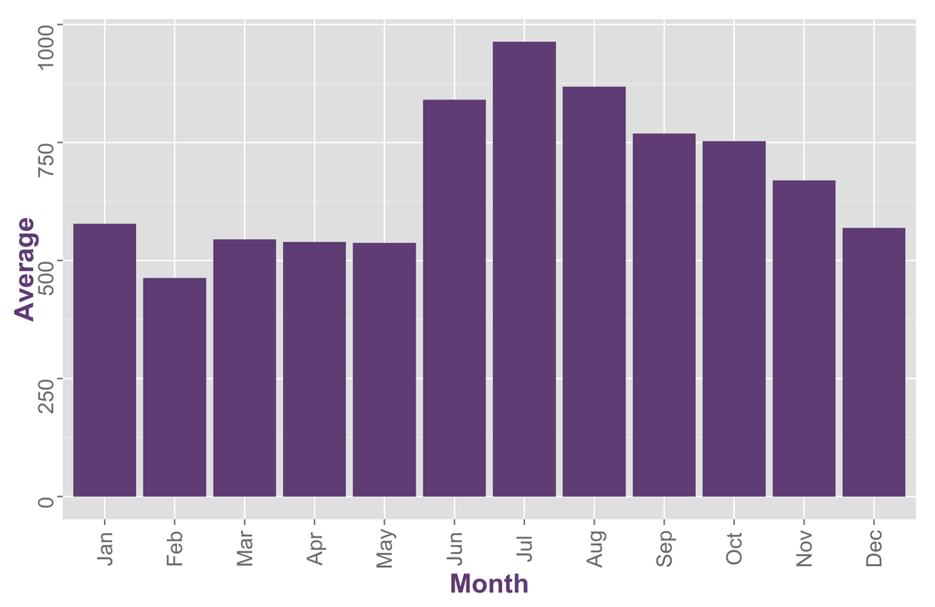

### *¿Tiempo promedio entre avistamientos por año?*

Podemos observar que los datos se parten en dos conjuntos: a partir del año 1995 se tiene un tiempo promedio entre avistamientos menor a 6 horas. Y de 1994 hacia atras se tiene de 1-2 dias entre avistamientos. La unica observacion atipica es el año 1900 y 1969 con 0 y 140 dias respectivamente pero esto era de esperarse ya que se tenian muy pocas o nulas observaciones, de tal forma que el tiempo promedio entre avistamientos es muy chico.

```r
select year, avg(difference) from (select line_number, date_time, date_time - lag(date_time) over (order by date_time) as difference, date_part('year', date_time) as year from sightings) t group by year order by year;
```

Por otro lado, el comportamiento promedio del numero de avistamientos de los ultimos dos años se ven asi:

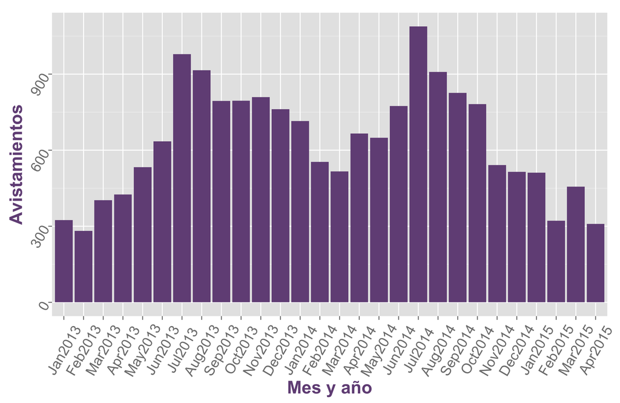

### *¿Promedio entre avistamientos por estado?*

Vemos que los top5 estados con menor tiempo entre avistamientos son: California, Nebraska, New-Hampshire y Carolina del Sur con menos de 5 hrs entre avistamientos. Los top 5 con mayor tiempo entre avistamientos son: North Dakota, Pensilvania, Alabama y Orlando.

Como hipotesis, podriamos decir que esperamos un menor tiempo promedio entre avistamientos para estados menos urbanizados y viceversa para estados mas urbanizados. Si bien lo encontrado anterior es un proxy a esta informacion, posiblemente una manera de corroborar la afirmacion es ponderando por la poblacion de cada estado, pues a pesar de que estados altamente alfabetizados como Nueva York tienen un tiempo de 14 hrs, tambien es cierto que es un estado muy poblado, lo cual tendera a alzar este numero.

```r
select state_str, avg(difference) from (select line_number, date_time, date_time - lag(date_time) over (order by date_time) as difference,   state_str from sightings) t  group by state_str ;
```

### *¿Cuál es el estado con mayor varianza?*

California el de mayor varianza lo que significa que los avistamientos no estan distribuidos uniformemente a lo largo del tiempo. Pensilvania el de menor varianza.

```r
select state_str, variance(count) as variance from (select state_str, date_part('month', date_time) as month, date_part('year', date_time) as year, count(*) as count  from sightings group by state_str, month, year order by state_str, month, year) t group by state_str order by variance DESC;
```

### *¿Existen olas temporales?*

Si, y en todos los años, pues obtenemos que siempre hay rachas de al menos tamaño 2. Pero no sabemos que tan grandes son estas olas.

```r
select month, year, count(*) from (select line_number, date_time, year, month, extract(epoch from difference)/3600 as hour_diff from (select line_number, date_time, date_time - lag(date_time) over (order by date_time) as difference, date_part('year', date_time) as year, date_part('month', date_time) as month from sightings) t) t1 where 24< hour_diff and hour_diff <= 48 group by month, year order by year, month;
```

### *¿Existen olas espacio- temporales?*

Si, en algunos estados, pero mucho menos marcadas que las temporales exclusivamente.

```r
select state_str, month, year, count(*) as count from (select line_number, date_time, state_str, year, month, extract(epoch from difference)/3600 as hour_diff from (select line_number, state_str, date_time, date_time - lag(date_time) over (order by date_time) as difference, date_part('year', date_time) as year, date_part('month', date_time) as month from sightings) t) t1 where 24< hour_diff and hour_diff <= 48 group by state_str, month, year order by state_str, count DESC;
```

### *¿Relacionado con la geografia?*

No se encontro que este relacionado de manera notoria con la ciudad de procedencia por estado:

```r
select state_str, city_str, count(*) as count from sightings group by state_str, city_str order by state_str, city_str, count;
```

### *¿Narrativas parecidas?*

Para esto se uso el paquete de postgres para analizar similaridades:

```r
select date_time, city_str, state_str, similarity(summary, lag(summary) over (order by date_time, state_str)) as simil from sightings order by state_str, date_time;
```

### Modelo predictivo para avistamientos:

El modelo predictivo se desarrollo usando R.

Como es usual, primero cargamos las librerias que vamos a utilizar:

```r
library(rmarkdown)
library(ggplot2)
library(RPostgreSQL)
```

Usamos el paquete *RPostgreSQL* el cual nos permitira conectar Postgres con R.

Para la conexion con Postgres usamos la siguiente instruccion:

```r
drv <- dbDriver("PostgreSQL")
```

Posteriormente hacemos conexion a las base de datos que hay en la maquina y guardamos la de *Avistamientos*:

```r
con <- dbConnect(drv, dbname="bigdata", user="postgres")
ufo<- dbReadTable(con,"sightings")
```

Y entonces ya podemos trabajar con *ufo* como si fuera un dataframe de R y llevar a cabo nuestro modelo de prediccion. Primero vemos las columnas:

```r
ufo = read.csv("ufo_.csv")
colnames(ufo)
```

```
## [1] "obs"      "date"     "time"     "state"    "shape"    "duration"
## [7] "posted"   "Year"
```

Serie de tiempo global:

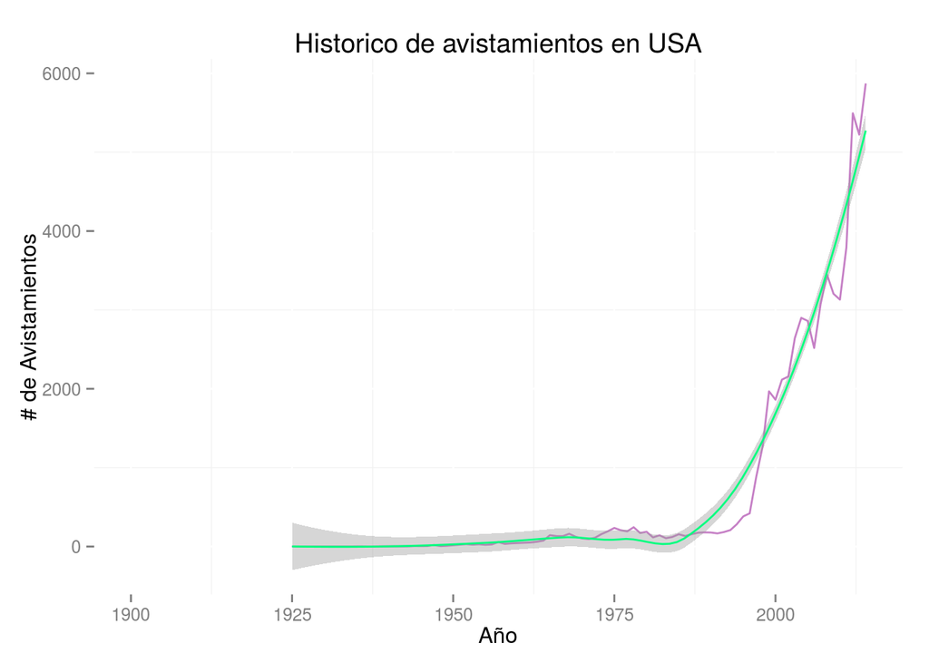

```r
history <- plyr::count(ufo$Year)
plot.global <- ggplot(data = history, aes(x = x, y = freq )) +
       geom_line(alpha = .5, color = "darkmagenta") +
       geom_smooth(color = "springgreen1") +
       xlab("Año") +
       ylab("# de Avistamientos") +
       ggtitle("Historico de avistamientos en USA") +
       xlim(1900,2014)+
       theme(panel.background = element_blank())
plot.global
```